# measure-panels

Steve Simon

September 17, 2016

The following code is part of an R Cheat Sheet, How Big Is Your Graph.

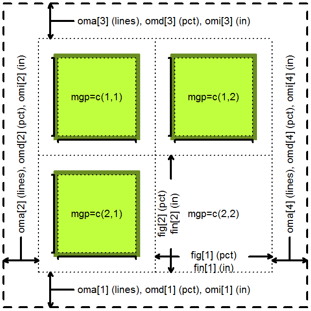

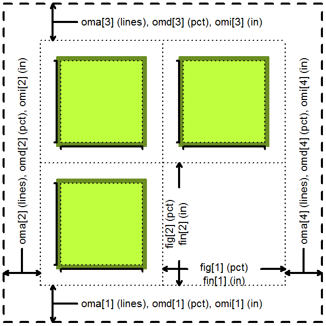

## Panels

**par(“fig”)** (width, height) in pct

**par(“fin”)** (width, height) in inches

If you display multiple plots within a single graphics window (e.g., with **mfrow** or **mfcol** arguments of **par** or with the **layout** function), then the **fig** and **fin** arguments will tell you the size of the current subplot window in percent or inches, respectively.

**par(“oma”)** (bottom, left, top, right) in lines

**par(“omd”)** (bottom, left, top, right) in pct

**par(“omi”)** (bottom, left, top, right) in inches

Each subplot will have margins specified by **mai** or **mar**, but there are no outer margin around the entire set of plots, unless you specify them using **oma**, **omd**, or **omi**. You can place text in the outer margins using the **mtext** function with the argument **outer=TRUE**.